# Diagnostic for Heart Disease using KNN classification

by Rosa Rezaei, Ishraq Mostafa, Advitya Mittal and Quincy Kuzyk

## Introduction

According to Statistics Canada (2), heart disease is the second leading cause of death in Canada and the leading cause of death in the United States of America, Canada’s nearest neighbor. The relatively broad term ‘heart disease’ can include a number of different health issues within the heart, including, but not limited to: coronary artery disease, congenital heart disease, arrhythmia, myocardial infarction and heart failure (2). This investigation’s aim is to figure out which variable in relation to a patient’s health can be best used to predict whether or not a patient will have heart disease or is at a high risk from it. The dataset that will be used for the investigation is the Cleveland Heart Disease Dataset. This dataset includes the medical data of 303 individuals from Cleveland Ohio. One of the variable columns in the dataset includes the diagnosis of heart disease in each patient. Whether they suffer from it or not as well as how severe their case may be. Each patient is assigned a number value from 0 to 4, 0 representing no heart disease, then 1 to 4 representing the presence of heart disease. The severity of the disease increases with the number. The aim of this investigation is to evaluate which observations from the Cleveland Heart Disease dataset are most closely related with the diagnosis of heart disease, with 0 representing no risk and any value above that representing risk of heart disease. Our analysis conducts k-nn classification to predict whether someone is at risk for heart disease or not.

Attribute information:

- Age: age of the individual (years)
- Sex: gender of the individual 1 = male 0 = female
- Chest-pain type: type of chest-pain experienced by the individual 1 = typical angina 2 = atypical angina 3 = non anginal pain 4 = asymptotic
- Resting Blood Pressure: resting blood pressure value of an individual (in mmHg)
- Serum Cholestrol: serum cholesterol (mg/dl unit)
- Fasting Blood Sugar: compares the fasting blood sugar value of an individual with 120mg/dl. If fasting blood sugar > 120mg/dl then : 1 (true) else : 0 (false)
- Resting ECG : resting electrocardiographic results 0 = normal 1 = having ST-T wave abnormality 2 = left ventricular hyperthrophy
- Max heart rate achieved : max heart rate achieved by an individual.
- Exercise induced angina : 1 = yes 0 = no
- ST depression induced by exercise relative to rest: displays the value which is an integer or float.
- Peak exercise ST segment : 1 = upsloping 2 = flat 3 = downsloping
- Number of major vessels (0–3) colored by flourosopy : integer or float.
- Thal : thalassemia : 3 = normal 6 = fixed defect 7 = reversible defect

The libraries and coding packages used in this analysis are: tidyverse, caret, ggplot2, forcats, GGally.

```r
library(tidyverse)
library(caret)
library(ggplot2)
library(forcats)
library(GGally)
```

## 1. Load Data

#### First we load the data set from Cleaveland Heart Disease Database from the web

```r
heart_disease_data <- read_csv("http://archive.ics.uci.edu/ml/machine-learning-databases/heart-disease/processed.cleveland.data", col_names = FALSE)
head(heart_disease_data)
```

A tibble: 6 × 14

| X1 <dbl> | X2 <dbl> | X3 <dbl> | X4 <dbl> | X5 <dbl> | X6 <dbl> | X7 <dbl> | X8 <dbl> | X9 <dbl> | X10 <dbl> | X11 <dbl> | X12 <chr> | X13 <chr> | X14 <dbl> |
| --- | --- | --- | --- | --- | --- | --- | --- | --- | --- | --- | --- | --- | --- |
| 63 | 1 | 1 | 145 | 233 | 1 | 2 | 150 | 0 | 2.3 | 3 | 0.0 | 6.0 | 0 |
| 67 | 1 | 4 | 160 | 286 | 0 | 2 | 108 | 1 | 1.5 | 2 | 3.0 | 3.0 | 2 |
| 67 | 1 | 4 | 120 | 229 | 0 | 2 | 129 | 1 | 2.6 | 2 | 2.0 | 7.0 | 1 |
| 37 | 1 | 3 | 130 | 250 | 0 | 0 | 187 | 0 | 3.5 | 3 | 0.0 | 3.0 | 0 |
| 41 | 0 | 2 | 130 | 204 | 0 | 2 | 172 | 0 | 1.4 | 1 | 0.0 | 3.0 | 0 |
| 56 | 1 | 2 | 120 | 236 | 0 | 0 | 178 | 0 | 0.8 | 1 | 0.0 | 3.0 | 0 |

## 2. Clean Data

#### We add column names

```r
colnames(heart_disease_data) <- c('age', 'sex', 'cp', 'trestbps', 'chol', 'fbs', 'restecg', 'thalach', 'exang', 'oldpeak', 'slope', 'ca', 'thal', 'target')
head(heart_disease_data)
```

A tibble: 6 × 14

| age <dbl> | sex <dbl> | cp <dbl> | trestbps <dbl> | chol <dbl> | fbs <dbl> | restecg <dbl> | thalach <dbl> | exang <dbl> | oldpeak <dbl> | slope <dbl> | ca <chr> | thal <chr> | target <dbl> |
| --- | --- | --- | --- | --- | --- | --- | --- | --- | --- | --- | --- | --- | --- |
| 63 | 1 | 1 | 145 | 233 | 1 | 2 | 150 | 0 | 2.3 | 3 | 0.0 | 6.0 | 0 |
| 67 | 1 | 4 | 160 | 286 | 0 | 2 | 108 | 1 | 1.5 | 2 | 3.0 | 3.0 | 2 |
| 67 | 1 | 4 | 120 | 229 | 0 | 2 | 129 | 1 | 2.6 | 2 | 2.0 | 7.0 | 1 |
| 37 | 1 | 3 | 130 | 250 | 0 | 0 | 187 | 0 | 3.5 | 3 | 0.0 | 3.0 | 0 |
| 41 | 0 | 2 | 130 | 204 | 0 | 2 | 172 | 0 | 1.4 | 1 | 0.0 | 3.0 | 0 |
| 56 | 1 | 2 | 120 | 236 | 0 | 0 | 178 | 0 | 0.8 | 1 | 0.0 | 3.0 | 0 |

#### Then we remove any observations with missing values.

```r
heart_disease_data[heart_disease_data == "?"] <- NA
clean_heart <- na.omit(heart_disease_data)
sum(is.na(heart_disease_data))


head(clean_heart)
```

6

A tibble: 6 × 14

| age <dbl> | sex <dbl> | cp <dbl> | trestbps <dbl> | chol <dbl> | fbs <dbl> | restecg <dbl> | thalach <dbl> | exang <dbl> | oldpeak <dbl> | slope <dbl> | ca <chr> | thal <chr> | target <dbl> |
| --- | --- | --- | --- | --- | --- | --- | --- | --- | --- | --- | --- | --- | --- |
| 63 | 1 | 1 | 145 | 233 | 1 | 2 | 150 | 0 | 2.3 | 3 | 0.0 | 6.0 | 0 |
| 67 | 1 | 4 | 160 | 286 | 0 | 2 | 108 | 1 | 1.5 | 2 | 3.0 | 3.0 | 2 |
| 67 | 1 | 4 | 120 | 229 | 0 | 2 | 129 | 1 | 2.6 | 2 | 2.0 | 7.0 | 1 |
| 37 | 1 | 3 | 130 | 250 | 0 | 0 | 187 | 0 | 3.5 | 3 | 0.0 | 3.0 | 0 |
| 41 | 0 | 2 | 130 | 204 | 0 | 2 | 172 | 0 | 1.4 | 1 | 0.0 | 3.0 | 0 |
| 56 | 1 | 2 | 120 | 236 | 0 | 0 | 178 | 0 | 0.8 | 1 | 0.0 | 3.0 | 0 |

#### Target has five levels of : 0, 1, 2, 3, 4 but we’re only interested in predicting a patient has heart disease or not, so our target labels will be:

#### 0 = No Disease

#### 1 = Disease

#### We will change the integer variables “2”, “3”, and “4” to “1” in the target column, so only “0” and “1” variables remain.

```r
clean_heart$target[clean_heart$target=="4"] <- "1"
clean_heart$target[clean_heart$target=="3"] <- "1"
clean_heart$target[clean_heart$target=="2"] <- "1"



head(clean_heart)
```

A tibble: 6 × 14

| age <dbl> | sex <dbl> | cp <dbl> | trestbps <dbl> | chol <dbl> | fbs <dbl> | restecg <dbl> | thalach <dbl> | exang <dbl> | oldpeak <dbl> | slope <dbl> | ca <chr> | thal <chr> | target <chr> |
| --- | --- | --- | --- | --- | --- | --- | --- | --- | --- | --- | --- | --- | --- |
| 63 | 1 | 1 | 145 | 233 | 1 | 2 | 150 | 0 | 2.3 | 3 | 0.0 | 6.0 | 0 |
| 67 | 1 | 4 | 160 | 286 | 0 | 2 | 108 | 1 | 1.5 | 2 | 3.0 | 3.0 | 1 |
| 67 | 1 | 4 | 120 | 229 | 0 | 2 | 129 | 1 | 2.6 | 2 | 2.0 | 7.0 | 1 |
| 37 | 1 | 3 | 130 | 250 | 0 | 0 | 187 | 0 | 3.5 | 3 | 0.0 | 3.0 | 0 |
| 41 | 0 | 2 | 130 | 204 | 0 | 2 | 172 | 0 | 1.4 | 1 | 0.0 | 3.0 | 0 |
| 56 | 1 | 2 | 120 | 236 | 0 | 0 | 178 | 0 | 0.8 | 1 | 0.0 | 3.0 | 0 |

#### Since target is the label we want to predict, we must change it to a factor. We also changed "ca" and "thal" to numerical variables because k-nn requires are predictors to be numerical.

```r
clean_heart2 <- clean_heart %>%
mutate(target = as.factor(target)) %>%
mutate(thal = as.numeric(thal)) %>%
mutate(ca = as.numeric(ca))

head(clean_heart2)
```

A tibble: 6 × 14

| age <dbl> | sex <dbl> | cp <dbl> | trestbps <dbl> | chol <dbl> | fbs <dbl> | restecg <dbl> | thalach <dbl> | exang <dbl> | oldpeak <dbl> | slope <dbl> | ca <dbl> | thal <dbl> | target <fct> |
| --- | --- | --- | --- | --- | --- | --- | --- | --- | --- | --- | --- | --- | --- |
| 63 | 1 | 1 | 145 | 233 | 1 | 2 | 150 | 0 | 2.3 | 3 | 0 | 6 | 0 |
| 67 | 1 | 4 | 160 | 286 | 0 | 2 | 108 | 1 | 1.5 | 2 | 3 | 3 | 1 |
| 67 | 1 | 4 | 120 | 229 | 0 | 2 | 129 | 1 | 2.6 | 2 | 2 | 7 | 1 |
| 37 | 1 | 3 | 130 | 250 | 0 | 0 | 187 | 0 | 3.5 | 3 | 0 | 3 | 0 |
| 41 | 0 | 2 | 130 | 204 | 0 | 2 | 172 | 0 | 1.4 | 1 | 0 | 3 | 0 |
| 56 | 1 | 2 | 120 | 236 | 0 | 0 | 178 | 0 | 0.8 | 1 | 0 | 3 | 0 |

#### Now let's check to see how many levels our labels have. We should expect 2.

```r
clean_heart2 %>%
  select(target) %>%
  unlist() %>%
  levels()
```

1. '0'

2. '1'

#### Now we must check to see the number of observations our data set contains for each of our class labels. This is important because unequal representation can lead to inaccurate predictions.

```r
num_obs <- nrow(clean_heart2)

 clean_heart2 %>%
  group_by(target) %>%
  summarize(n = n(),
            percentage = n() / num_obs * 100)
```

A tibble: 2 × 3

| target <fct> | n <int> | percentage <dbl> |
| --- | --- | --- |
| 0 | 160 | 53.87205 |
| 1 | 137 | 46.12795 |

#### Before we go further, we check to see the difference in values of the variables using str function. Significantly different values will influence our classification at varying degrees which will make our predications less accurate.

```r
str(clean_heart2)
```

```
Classes ‘tbl_df’, ‘tbl’ and 'data.frame':	297 obs. of  14 variables:
 $ age     : num  63 67 67 37 41 56 62 57 63 53 ...
 $ sex     : num  1 1 1 1 0 1 0 0 1 1 ...
 $ cp      : num  1 4 4 3 2 2 4 4 4 4 ...
 $ trestbps: num  145 160 120 130 130 120 140 120 130 140 ...
 $ chol    : num  233 286 229 250 204 236 268 354 254 203 ...
 $ fbs     : num  1 0 0 0 0 0 0 0 0 1 ...
 $ restecg : num  2 2 2 0 2 0 2 0 2 2 ...
 $ thalach : num  150 108 129 187 172 178 160 163 147 155 ...
 $ exang   : num  0 1 1 0 0 0 0 1 0 1 ...
 $ oldpeak : num  2.3 1.5 2.6 3.5 1.4 0.8 3.6 0.6 1.4 3.1 ...
 $ slope   : num  3 2 2 3 1 1 3 1 2 3 ...
 $ ca      : num  0 3 2 0 0 0 2 0 1 0 ...
 $ thal    : num  6 3 7 3 3 3 3 3 7 7 ...
 $ target  : Factor w/ 2 levels "0","1": 1 2 2 1 1 1 2 1 2 2 ...
```

#### Here we can see that age, trestbps, chol and thalach are greater values and hence the data will need to be standardized (will be done in part 3). Without standardization, predictors will have unequal effect on our classifier and hence lead to inaccurate predictions.

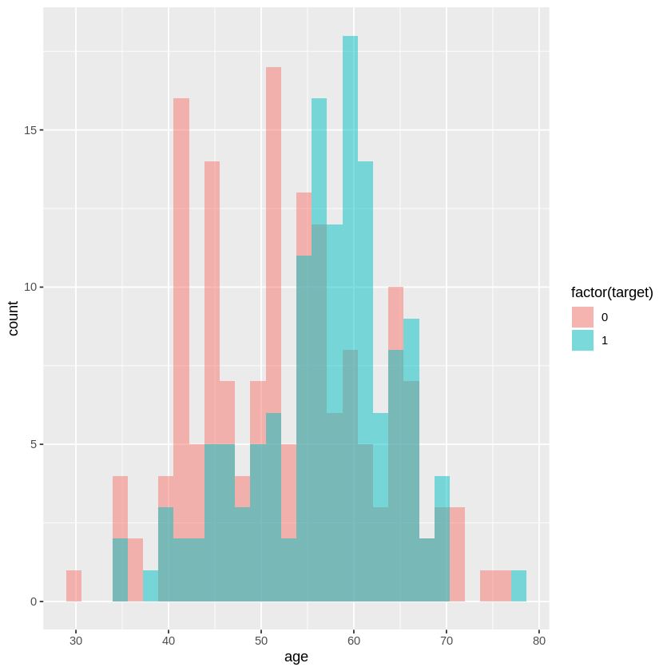

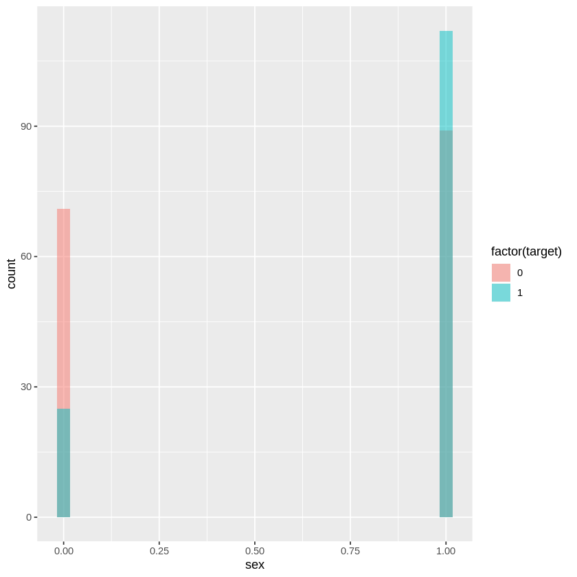

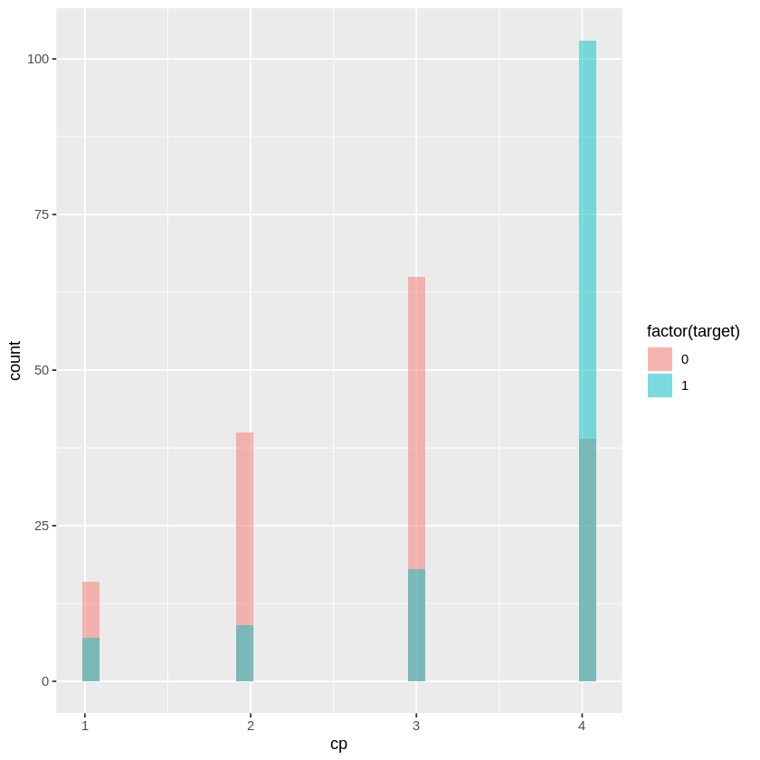

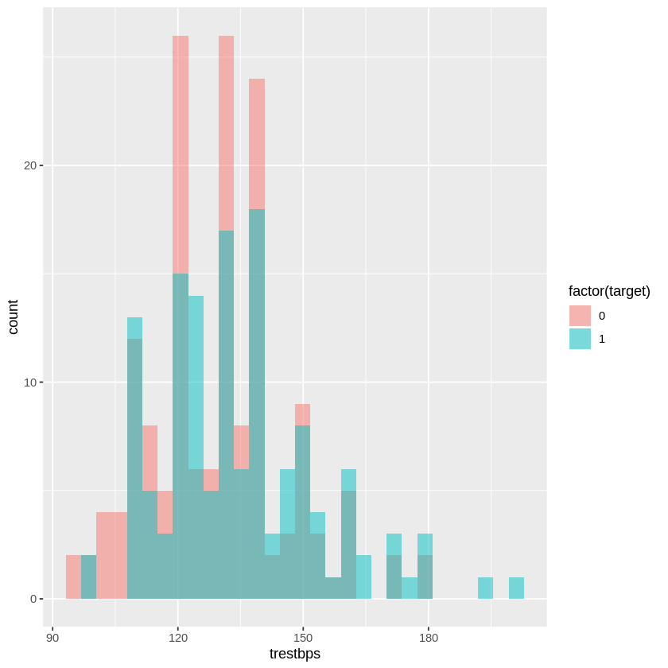

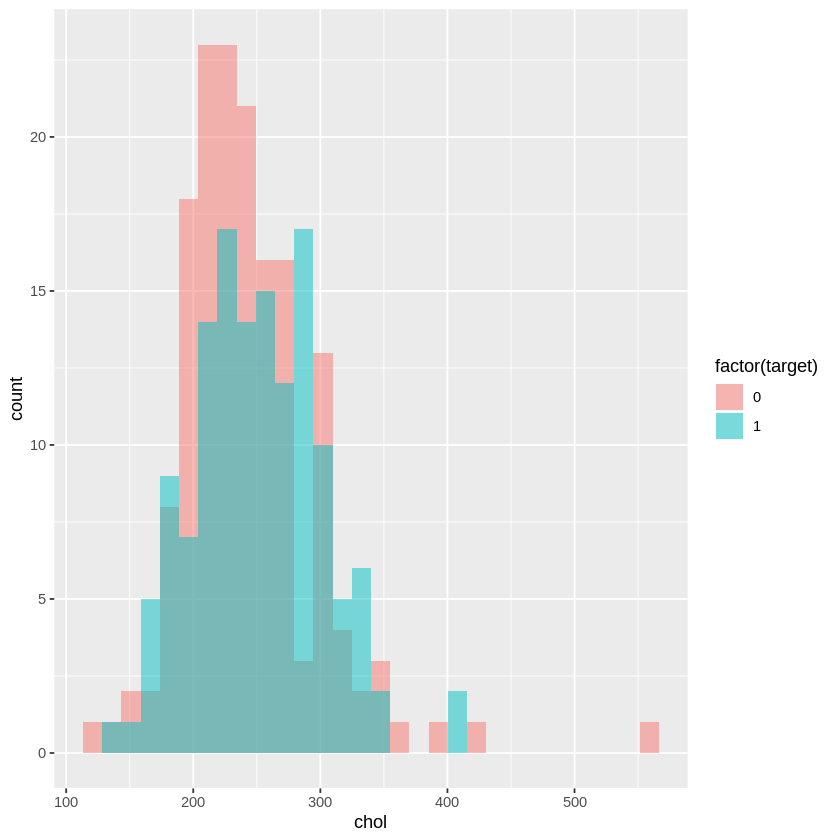

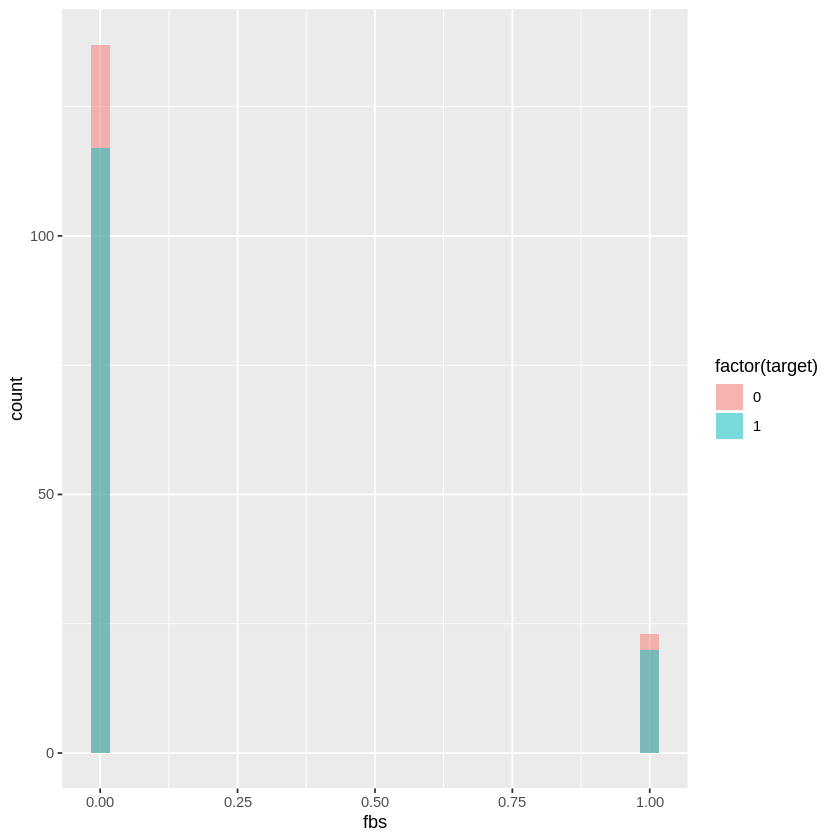

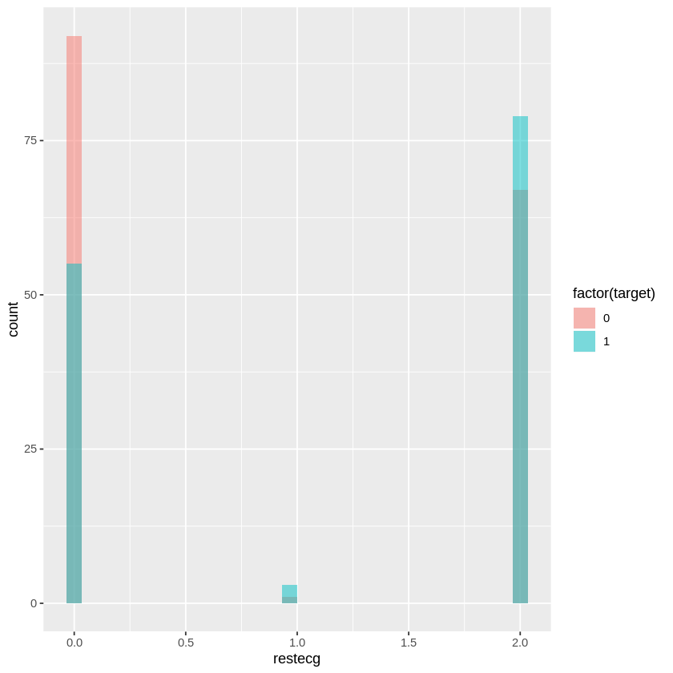

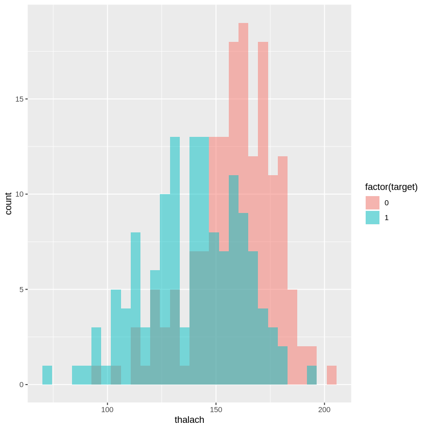

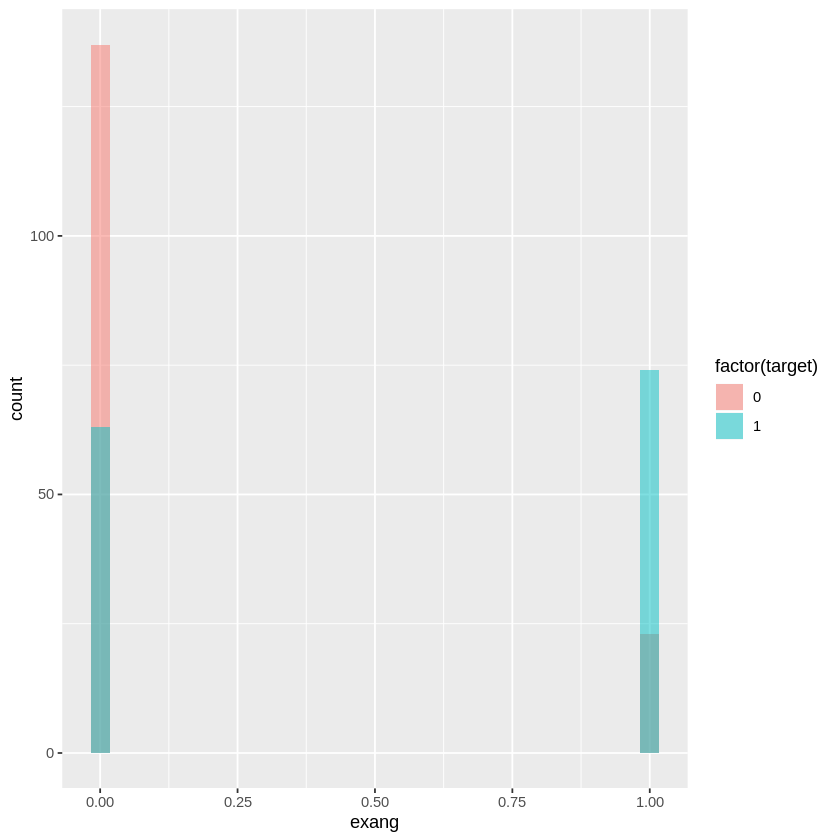

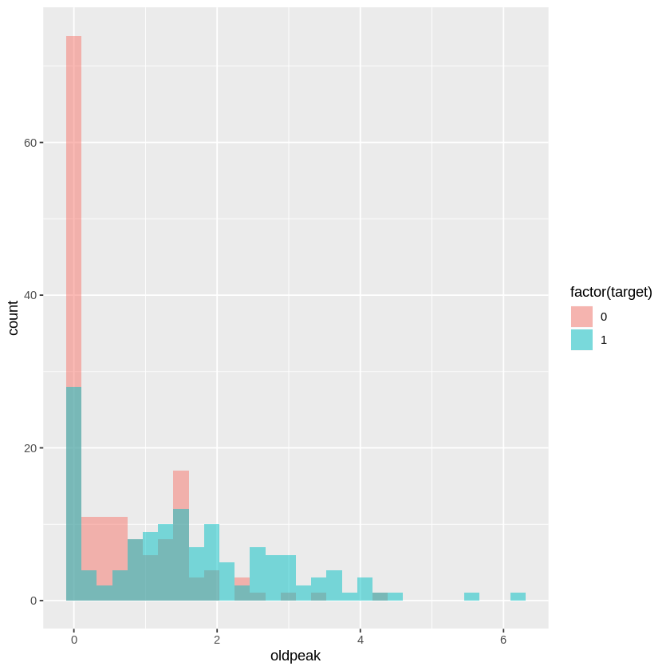

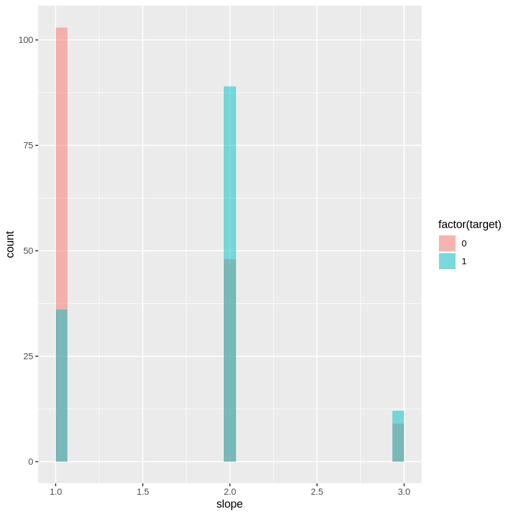

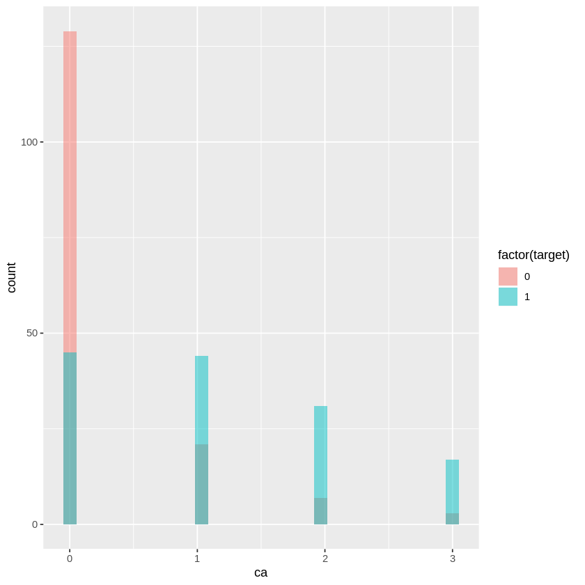

[1 more figures not shown]

```r
heart_age <- ggplot(clean_heart2, aes(x = age, fill = factor(target))) +
                 geom_histogram(position = "identity", alpha = 0.5)
heart_sex <- ggplot(clean_heart2, aes(x = sex, fill = factor(target))) +
                 geom_histogram(position = "identity", alpha = 0.5)
heart_cp <- ggplot(clean_heart2, aes(x = cp, fill = factor(target))) +
                 geom_histogram(position = "identity", alpha = 0.5)
heart_trestbps <- ggplot(clean_heart2, aes(x = trestbps, fill = factor(target))) +
                 geom_histogram(position = "identity", alpha = 0.5)
heart_chol <- ggplot(clean_heart2, aes(x = chol, fill = factor(target))) +
                 geom_histogram(position = "identity", alpha = 0.5)
heart_fbs <- ggplot(clean_heart2, aes(x = fbs, fill = factor(target))) +
                 geom_histogram(position = "identity", alpha = 0.5)
heart_restecg <- ggplot(clean_heart2, aes(x = restecg, fill = factor(target))) +
                 geom_histogram(position = "identity", alpha = 0.5)
heart_thalach <- ggplot(clean_heart2, aes(x = thalach, fill = factor(target))) +
                 geom_histogram(position = "identity", alpha = 0.5)
heart_exang <- ggplot(clean_heart2, aes(x = exang, fill = factor(target))) +
                 geom_histogram(position = "identity", alpha = 0.5)
heart_oldpeak <- ggplot(clean_heart2, aes(x = oldpeak, fill = factor(target))) +
                 geom_histogram(position = "identity", alpha = 0.5)
heart_slope <- ggplot(clean_heart2, aes(x = slope, fill = factor(target))) +
                 geom_histogram(position = "identity", alpha = 0.5)
heart_ca <- ggplot(clean_heart2, aes(x = ca, fill = factor(target))) +
                 geom_histogram(position = "identity", alpha = 0.5)
heart_thal <- ggplot(clean_heart2, aes(x = thal, fill = factor(target))) +
                 geom_histogram(position = "identity", alpha = 0.5)
heart_age
heart_sex
heart_cp
heart_trestbps
heart_chol
heart_fbs
heart_restecg
heart_thalach
heart_exang
heart_oldpeak
heart_slope
heart_ca
heart_thal
```

## 3. Splitting the data into training and test set

```r
set.seed(1)

training_rows <- clean_heart2 %>%
    select(target) %>%
    unlist() %>%
    createDataPartition(p = 0.70, list = FALSE)
```

#### Using the rows designated above, we use the slice function to create rows for the training set and testing set

```r
training_set <- clean_heart2 %>%
               slice(training_rows)

test_set <- clean_heart2 %>%
               slice(-training_rows)

head(training_set)
```

A tibble: 6 × 14

| age <dbl> | sex <dbl> | cp <dbl> | trestbps <dbl> | chol <dbl> | fbs <dbl> | restecg <dbl> | thalach <dbl> | exang <dbl> | oldpeak <dbl> | slope <dbl> | ca <dbl> | thal <dbl> | target <fct> |
| --- | --- | --- | --- | --- | --- | --- | --- | --- | --- | --- | --- | --- | --- |
| 63 | 1 | 1 | 145 | 233 | 1 | 2 | 150 | 0 | 2.3 | 3 | 0 | 6 | 0 |
| 67 | 1 | 4 | 160 | 286 | 0 | 2 | 108 | 1 | 1.5 | 2 | 3 | 3 | 1 |
| 67 | 1 | 4 | 120 | 229 | 0 | 2 | 129 | 1 | 2.6 | 2 | 2 | 7 | 1 |
| 37 | 1 | 3 | 130 | 250 | 0 | 0 | 187 | 0 | 3.5 | 3 | 0 | 3 | 0 |
| 53 | 1 | 4 | 140 | 203 | 1 | 2 | 155 | 1 | 3.1 | 3 | 0 | 7 | 1 |
| 57 | 1 | 4 | 140 | 192 | 0 | 0 | 148 | 0 | 0.4 | 2 | 0 | 6 | 0 |

```r
scale_transformer <- preProcess(clean_heart2, method = c("center", "scale"))
training_set <- predict(scale_transformer, clean_heart2)
test_set <- predict(scale_transformer, test_set)
head(training_set)
```

A tibble: 6 × 14

| age <dbl> | sex <dbl> | cp <dbl> | trestbps <dbl> | chol <dbl> | fbs <dbl> | restecg <dbl> | thalach <dbl> | exang <dbl> | oldpeak <dbl> | slope <dbl> | ca <dbl> | thal <dbl> | target <fct> |
| --- | --- | --- | --- | --- | --- | --- | --- | --- | --- | --- | --- | --- | --- |
| 0.9346033 | 0.6899303 | -2.2368535 | 0.74911571 | -0.27597761 | 2.426332 | 1.008496 | 0.01746496 | -0.695246 | 1.0671642 | 2.2603305 | -0.7207596 | 0.6547723 | 0 |
| 1.3766051 | 0.6899303 | 0.8724078 | 1.59357687 | 0.74330055 | -0.410757 | 1.008496 | -1.81327350 | 1.433497 | 0.3811301 | 0.6426964 | 2.4742493 | -0.8927134 | 1 |
| 1.3766051 | 0.6899303 | 0.8724078 | -0.65831955 | -0.35290426 | -0.410757 | 1.008496 | -0.89790427 | 1.433497 | 1.3244270 | 0.6426964 | 1.4092463 | 1.1706008 | 1 |
| -1.9384088 | 0.6899303 | -0.1640127 | -0.09534545 | 0.05096067 | -0.410757 | -1.001728 | 1.63025836 | -0.695246 | 2.0962153 | 2.2603305 | -0.7207596 | -0.8927134 | 0 |
| -1.4964070 | -1.4445416 | -1.2004331 | -0.09534545 | -0.83369584 | -0.410757 | 1.008496 | 0.97642320 | -0.695246 | 0.2953758 | -0.9749377 | -0.7207596 | -0.8927134 | 0 |
| 0.1611000 | 0.6899303 | -1.2004331 | -0.65831955 | -0.21828262 | -0.410757 | -1.001728 | 1.23795726 | -0.695246 | -0.2191498 | -0.9749377 | -0.7207596 | -0.8927134 | 0 |

#### We summarize the training data set. The following tables show the number of observations of each case of target(risk), and the percentage as well. We also showed the mean of the predictor variables in another summary table.

```r
num_obs <- nrow(training_set)
training_set %>%
  group_by(target) %>%
  summarize(n = n(),
            percentage = n() / num_obs * 100)

training_set_summary <- group_by(training_set, target) %>%
    summarize(mean_trestbps = mean(trestbps),
              mean_chol = mean(chol),
              mean_thalach = mean(thalach),
              mean_age = mean(age),
              mean_oldpeak = mean(oldpeak),
              number_of_observations = length(target))
training_set_summary
```

A tibble: 2 × 3

| target <fct> | n <int> | percentage <dbl> |
| --- | --- | --- |
| 0 | 160 | 53.87205 |
| 1 | 137 | 46.12795 |

A tibble: 2 × 7

| target <fct> | mean_trestbps <dbl> | mean_chol <dbl> | mean_thalach <dbl> | mean_age <dbl> | mean_oldpeak <dbl> | number_of_observations <int> |
| --- | --- | --- | --- | --- | --- | --- |
| 0 | -0.1417908 | -0.07416534 | 0.3915132 | -0.2097672 | -0.3917302 | 160 |
| 1 | 0.1655951 | 0.08661645 | -0.4572416 | 0.2449836 | 0.4574952 | 137 |

## 4. Choosing K

#### We will use cross-validation to choose the best K based on all predictors. Target is our class label.

```r
X_train <- training_set %>%
  select(age, sex, cp, trestbps, chol, fbs, restecg, thalach, exang, oldpeak, slope, ca, thal) %>%
  data.frame()

Y_train <- training_set %>%
  select(target) %>%
  unlist()

head(X_train)
head(Y_train)
```

A data.frame: 6 × 13

| age <dbl> | sex <dbl> | cp <dbl> | trestbps <dbl> | chol <dbl> | fbs <dbl> | restecg <dbl> | thalach <dbl> | exang <dbl> | oldpeak <dbl> | slope <dbl> | ca <dbl> | thal <dbl> |
| --- | --- | --- | --- | --- | --- | --- | --- | --- | --- | --- | --- | --- |
| 0.9346033 | 0.6899303 | -2.2368535 | 0.74911571 | -0.27597761 | 2.426332 | 1.008496 | 0.01746496 | -0.695246 | 1.0671642 | 2.2603305 | -0.7207596 | 0.6547723 |
| 1.3766051 | 0.6899303 | 0.8724078 | 1.59357687 | 0.74330055 | -0.410757 | 1.008496 | -1.81327350 | 1.433497 | 0.3811301 | 0.6426964 | 2.4742493 | -0.8927134 |
| 1.3766051 | 0.6899303 | 0.8724078 | -0.65831955 | -0.35290426 | -0.410757 | 1.008496 | -0.89790427 | 1.433497 | 1.3244270 | 0.6426964 | 1.4092463 | 1.1706008 |
| -1.9384088 | 0.6899303 | -0.1640127 | -0.09534545 | 0.05096067 | -0.410757 | -1.001728 | 1.63025836 | -0.695246 | 2.0962153 | 2.2603305 | -0.7207596 | -0.8927134 |
| -1.4964070 | -1.4445416 | -1.2004331 | -0.09534545 | -0.83369584 | -0.410757 | 1.008496 | 0.97642320 | -0.695246 | 0.2953758 | -0.9749377 | -0.7207596 | -0.8927134 |
| 0.1611000 | 0.6899303 | -1.2004331 | -0.65831955 | -0.21828262 | -0.410757 | -1.001728 | 1.23795726 | -0.695246 | -0.2191498 | -0.9749377 | -0.7207596 | -0.8927134 |

**target1**

0

**target2**

1

**target3**

1

**target4**

0

**target5**

0

**target6**

0

**Levels**:**

1. '0'

2. '1'

#### We use c function to create a data frame ks with all the Ks we would like to try out and train control function passes on the additional information to the train function we use to train our classifier. Here we set the arguments to method = "cv" which stands for cross-validation and number = 10 for 10-fold cross-validation.

#### To help assess accuracy of each k we pass train_control to the trControl function and adds this as an argument to the train function. We then visualize the accuracies of each k to help us choose k.

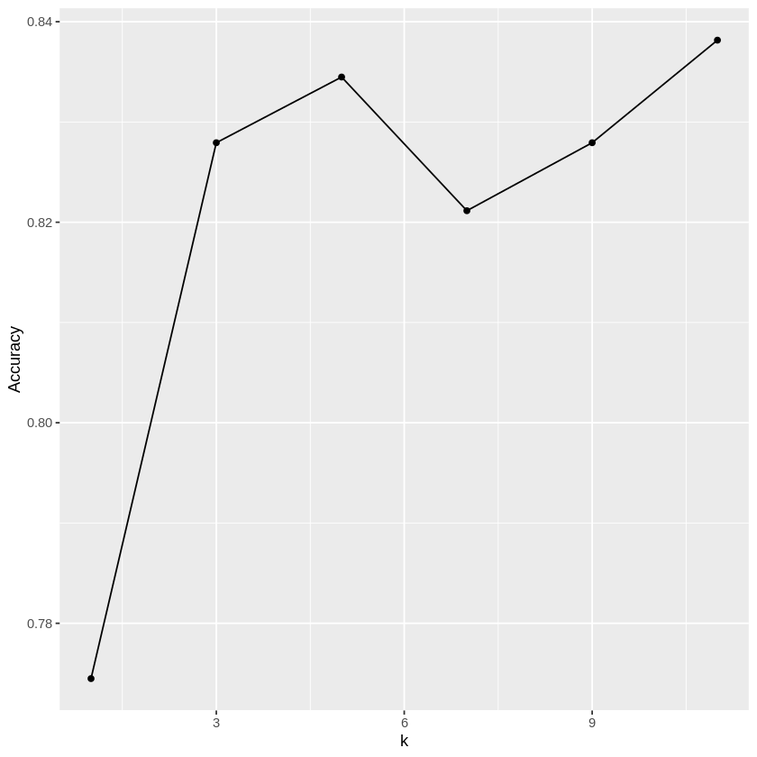

```r
set.seed(4321)

ks <- data.frame(k = c(1,3,5,7,9,11))
train_control <- trainControl(method = "cv", number = 10)



choose_k <- train(x = X_train, y = Y_train, method = "knn", tuneGrid = ks ,trControl = train_control)

k_accuracies <- choose_k$results %>%
select(k, Accuracy)


choose_k_plot <- ggplot(k_accuracies, aes(x = k, y = Accuracy)) +
                          geom_point() +
                         geom_line()
choose_k_plot
```

```r
k = data.frame(k = 5)

set.seed(9999)
model_knn <- train(x = X_train, y = Y_train, method = "knn", tuneGrid = k)
model_knn
```

```
k-Nearest Neighbors

297 samples
 13 predictor
  2 classes: '0', '1'

No pre-processing
Resampling: Bootstrapped (25 reps)
Summary of sample sizes: 297, 297, 297, 297, 297, 297, ...
Resampling results:

  Accuracy   Kappa
  0.8000026  0.5965531

Tuning parameter 'k' was held constant at a value of 5
```

#### Now we predict labels in our training set and evaluate the training accuracy using confusionMatrix function.

```r
set.seed(9999)

# your code here
predictions <- predict(model_knn, X_train)
training_results <- confusionMatrix(predictions, Y_train)
training_results
training_results$overall[1]
```

```
Confusion Matrix and Statistics

          Reference
Prediction   0   1
         0 145  19
         1  15 118

               Accuracy : 0.8855
                 95% CI : (0.8437, 0.9194)
    No Information Rate : 0.5387
    P-Value [Acc > NIR] : <2e-16

                  Kappa : 0.7692

 Mcnemar's Test P-Value : 0.6069

            Sensitivity : 0.9062
            Specificity : 0.8613
         Pos Pred Value : 0.8841
         Neg Pred Value : 0.8872
             Prevalence : 0.5387
         Detection Rate : 0.4882
   Detection Prevalence : 0.5522
      Balanced Accuracy : 0.8838

       'Positive' Class : 0
```

**Accuracy:** 0.885521885521885

## 5. Assessing our Model

```r
set.seed(4545)

X_test <- test_set %>%
  select(age, sex, cp, trestbps, chol, fbs, restecg, thalach, exang, oldpeak, slope, ca, thal) %>%
  data.frame()

Y_test <- test_set %>%
    select(target) %>%
    unlist()

test_pred <- predict(model_knn, X_test)
test_results <- confusionMatrix(test_pred, Y_test)
test_results$overall[1]
```

**Accuracy:** 0.865168539325843

#### We find that the classifier accuracy after using the model on the test data is 86.5%

# Conclusion

Our project goal was to predict whether someone is at risk for heart disease or not using k-nn classification.

The impact of our project could be life-saving. Patients can be diagnosed with risk of heart disease in a short time just from the data of the patients’ attributes. Further improvement on the overall functioning can make our predictions for the risk of heart disease even more accurate. This would not only allow the medical authority, but also the people at risk to be more cautious and aware about their health. After all, precaution is better than cure.

Further data collection and analysis could even make it possible to predict the level of risk of heart disease as well the type of heart disease. Besides guiding people to be able to keep better precaution, this can also help the Doctors in Diagnosing a fatal illness at an early stage.

## References

1. Centers for Disease Control and Prevention. “FastStats - Leading Causes of Death.” Centers for Disease Control and Prevention, Centers for Disease Control and Prevention, 17 Mar. 2017, www.cdc.gov/nchs/fastats/leading-causes-of-death.htm.
2. Statistics Canada. Statistics Canada: Canada's National Statistical Agency / Statistique Canada : Organisme Statistique National Du Canada, www150.statcan.gc.ca/t1/tbl1/en/tv.action?pid=1310039401.